# Programming with models (2): Inspecting model structure (state-space model example)

# The importance of querying a model: lifted nodes.

*You should never assume you know what nodes are in a model simply because you wrote the BUGS code.*

NIMBLE implements some features by inserting its own nodes.

Let’s look at the two main ways this happens:

```r
m1 <- nimbleModel(
    nimbleCode({
        tau ~ dunif(0, 100)
        x ~ dnorm(0, tau) #by default, tau is a precision
    }))
```

```
## defining model...
```

```
## building model...
```

```
## checking model...   (use nimbleModel(..., check = FALSE) to skip model check)
```

```
## NAs were detected in model variables: tau, logProb_tau, lifted_d1_over_sqrt_oPtau_cP, x, logProb_x.
```

```
## model building finished
```

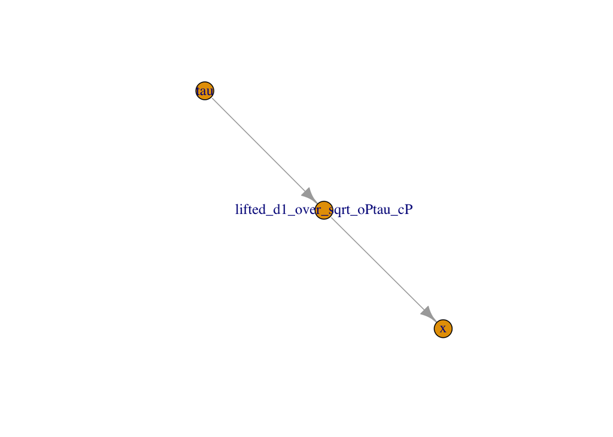

```r
plot(m1$getGraph())
```

```r
m1$getNodeNames()
```

```
## [1] "tau"                          "lifted_d1_over_sqrt_oPtau_cP"
## [3] "x"
```

The node `lifted_d1_over_sqrt_oPtau_cP` has been inserted between `tau` and `x`. The resulting model would equivalently have been created by this BUGS code:

```r
nimbleCode({
    tau ~ dunif(0, 100)
    lifted_d1_over_sqrt_oPtau_cP <- 1/sqrt(tau)
    x ~ dnorm(0, sd = lifted_d1_over_sqrt_oPtau_cP)
}))
```

NIMBLE has *lifted* the calculation of standard deviation from precision so that it is part of the model’s graph. Therefore *you will make a mistake if you assume that the dependencies of `tau` include only `x`*:

```r
m1$calculate(c('tau','x')) ## Wrong: the lifted node is being neglected
```

The correct way to do this is with model-generic programming:

```r
m1$calculate( m1$getDependencies('tau') )
```

The second common situation that creates lifted nodes is this:

```r
m2 <- nimbleModel(
    nimbleCode({
        a ~ dnorm(0, 1)
        b ~ dnorm(a + 1, 1)
    }))
```

```
## defining model...
```

```
## building model...
```

```
## checking model...   (use nimbleModel(..., check = FALSE) to skip model check)
```

```
## NAs were detected in model variables: a, logProb_a, lifted_a_plus_1, b, logProb_b.
```

```
## model building finished
```

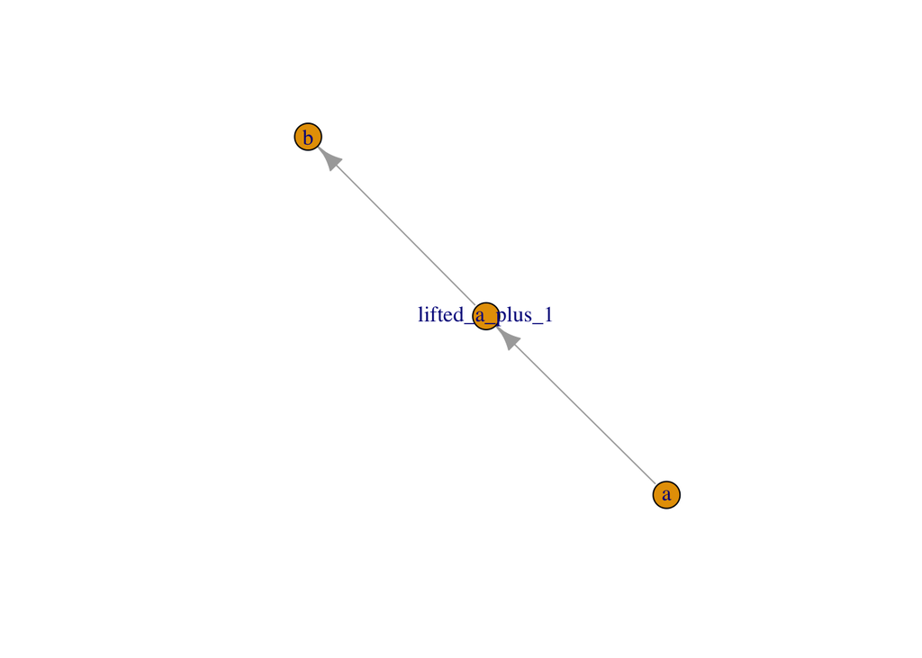

```r
plot(m2$getGraph())
```

```r
m2$getNodeNames()
```

```
## [1] "a"               "lifted_a_plus_1" "b"
```

In this case, NIMBLE lifted the expression `a+1` and created a node for it. Again the correct way to program is to query a model to learn about its nodes. Do not assume you know what the nodes are.

# Querying the sizes and types of model variables

Sometimes it is useful to ask a model about its *variables* and their sizes. As of the current version of NIMBLE, information about variables is not competely nicely arranged for a user (there aren’t as many query functions), but it is available:

```r
ssmSmall$getVarNames()
```

```
## [1] "logN.est"   "mean.r"     "sigma.proc" "sigma.obs"  "r"
## [6] "y"
```

```r
ssmSmall$getVarInfo('r')
```

```
## Reference class object of class "varInfoClass"
## Field "varName":
## [1] "r"
## Field "mins":
## [1] 1
## Field "maxs":
## [1] 4
## Field "nDim":
## [1] 1
## Field "anyStoch":
## [1] TRUE
```

This variable has 1 dimension (`nDim`), and its size is 4 (`maxs`). Currently `mins` is always 1. If at least one node within the variable is stochastic, then `anyStoch` will be `TRUE`.